# Seed rot data analysis

Alejandro Rojas

August 17, 2015

# Pathogenicity data analysis - Soybean oomycete pathogen survey

```
##      ggplot2 RColorBrewer         grid    gridExtra         plyr
##         TRUE         TRUE         TRUE         TRUE         TRUE
##         lme4      lsmeans        knitr        tidyr        dplyr
##         TRUE         TRUE         TRUE         TRUE         TRUE
##         MASS
##         TRUE
```

## Seed rot - Pathogenicity data

Processing the data for graphical exploration and analysis.

```r
#Reading the file
seed <- read.csv("../data/clean/seed_rot.csv")

#Summarizing data using different parameters by plyr library
seed_sum <- ddply(seed, c("Species", "Temp"), summarise,
              N = length(DIx100),
              mean_DI = mean(DIx100),
              sd_DI = sd(DIx100),
              se_DI = sd_DI/sqrt(N)
              )

#Setting limits for error bars
limits <- aes(ymax = mean_DI + se_DI, ymin=mean_DI - se_DI, col=Temp)
```

Plotting the data by temperature using standard error and summarizing data by species.

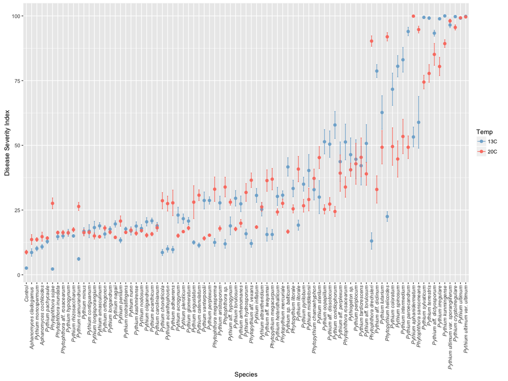

```r
#Creating plot for DI mean values
ggplot(seed_sum, aes(x=reorder(Species, mean_DI,median), y=mean_DI)) +
  geom_point(aes(colour=Temp), stat = "summary", fun.y="mean", size=2) +
  theme_gray() +
  theme(axis.text.x=element_text(angle=90, hjust = 1, vjust = 0.5, face="italic")) +
  scale_color_manual(values=c("#80b1d3","#fb8072")) +
  geom_errorbar(limits, width=0.2) +
  labs(x="Species", y="Disease Severity Index")
```

### Seed rot data for 20C

Subsetting the 20C seed rot assay data for statistical analysis, and testing different models to find the best fit:

- Species as fixed effect
- Species as fixed effect and experiment as random factor
- Species as fixed effect, experiment as random factor and Isolates nested within species

```r
#Dataset for 20C for seed rot
Seed_20C <- subset(seed, seed$Temp=="20C")

#General model AOV
fit1_20C <- aov(DIx100 ~ Species, data=Seed_20C)
summary(fit1_20C, adjust="bon")
```

```
##               Df  Sum Sq Mean Sq F value Pr(>F)
## Species       84 1232010   14667   64.89 <2e-16 ***
## Residuals   1841  416133     226
## ---
## Signif. codes:  0 '***' 0.001 '**' 0.01 '*' 0.05 '.' 0.1 ' ' 1
```

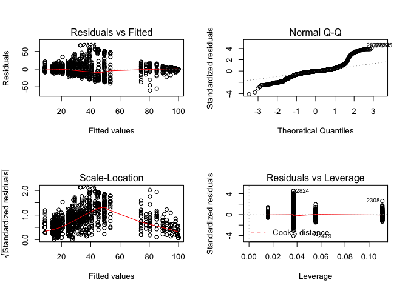

```r
#Plotting diagnostic plots for fit1 model
par(mfrow=c(2,2)) # optional layout
plot(fit1_20C)# diagnostic plots
```

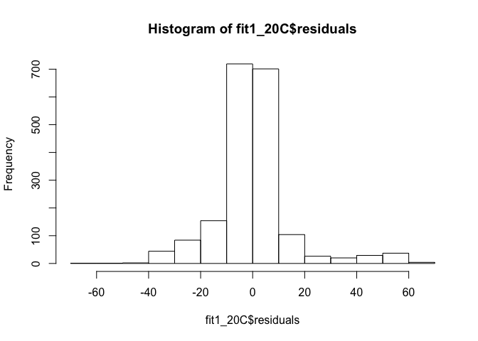

```r
#Plotting residuals
par(mfrow=c(1,1)) # optional layout
hist(fit1_20C$residuals)
```

```r
#Test with random effect fit2 using aov
fit1.2_20C <- aov(DIx100 ~ Species + Species:Isolate + Error(Set), data=Seed_20C)
summary(fit1.2_20C, adjust="bon")
```

```
##
## Error: Set
##           Df Sum Sq Mean Sq F value   Pr(>F)
## Species    6 278397   46399   42.26 3.52e-08 ***
## Residuals 14  15370    1098
## ---
## Signif. codes:  0 '***' 0.001 '**' 0.01 '*' 0.05 '.' 0.1 ' ' 1
##
## Error: Within
##                   Df Sum Sq Mean Sq F value Pr(>F)
## Species           84 954066   11358  207.13 <2e-16 ***
## Species:Isolate  123 307200    2498   45.55 <2e-16 ***
## Residuals       1698  93111      55
## ---
## Signif. codes:  0 '***' 0.001 '**' 0.01 '*' 0.05 '.' 0.1 ' ' 1
```

```r
##Model 2 with fixed effect (species) and random effect (set)
fit2_20C <- lmer(DIx100 ~ Species + (1|Set), data=Seed_20C, REML = FALSE)
summary(fit2_20C)
```

```
## Linear mixed model fit by maximum likelihood  ['lmerMod']
## Formula: DIx100 ~ Species + (1 | Set)
##    Data: Seed_20C
##
##      AIC      BIC   logLik deviance df.resid
##  15967.2  16451.2  -7896.6  15793.2     1839
##
## Scaled residuals:
##     Min      1Q  Median      3Q     Max
## -3.9299 -0.3294 -0.0364  0.2355  4.5421
##
## Random effects:
##  Groups   Name        Variance Std.Dev.
##  Set      (Intercept)   5.666   2.38
##  Residual             210.313  14.50
## Number of obs: 1926, groups:  Set, 21
##
## Fixed effects:
##                                            Estimate Std. Error t value
## (Intercept)                                 13.1630     5.0136   2.625
## SpeciesAphanomyces cochlioides               1.6928     7.0874   0.239
## SpeciesControl                              -4.4328     5.3108  -0.835
## SpeciesPhytophthora aff. rosacearum          3.2668     5.8867   0.555
## SpeciesPhytophthora drechsleri              77.1237     7.0874  10.882
## SpeciesPhytophthora inundata                 3.1837     5.8867   0.541
## SpeciesPhytophthora megasperma              19.9015     7.0874   2.808
## SpeciesPhytophthora rosacearum              20.8594     5.8867   3.544
## SpeciesPhytophthora sansomeana              81.1111     5.9205  13.700
## SpeciesPhytophthora sojae                   13.9815     5.5819   2.505
## SpeciesPhytophthora sp.                     20.7348     7.0874   2.926
## SpeciesPhytopythium aff. vexans             23.3737     6.2087   3.765
## SpeciesPhytopythium chamaehyphon            24.1928     5.8867   4.110
## SpeciesPhytopythium helicoides              78.7903     6.2087  12.690
## SpeciesPhytopythium litorale                12.4751     5.8867   2.119
## SpeciesPhytopythium megacarpum              23.7903     7.0874   3.357
## SpeciesPhytopythium mercuriale              14.6047     5.8867   2.481
## SpeciesPythiogeton sp.                      27.4015     7.0874   3.866
## SpeciesPythium acanthicum                    2.7321     5.8867   0.464
## SpeciesPythium acanthophoron                14.3459     7.0874   2.024
## SpeciesPythium acrogynum                     1.9800     5.8867   0.336
```

[output cut: 49 more lines]

```
## SpeciesPythium pleroticum                    3.4295     5.8867   0.583
## SpeciesPythium pyrilobum                    13.5126     7.0874   1.907
## SpeciesPythium rhizosaccharum                4.2949     5.8867   0.730
## SpeciesPythium rostratifingens               3.3802     5.8867   0.574
## SpeciesPythium sp. balticum                  3.4295     5.8867   0.583
## SpeciesPythium spinosum                     31.7135     5.8867   5.387
## SpeciesPythium sterilum                     32.1237     7.0874   4.532
## SpeciesPythium sylvaticum                   60.8333     5.5819  10.898
## SpeciesPythium tardicrescens                32.3825     5.8867   5.501
## SpeciesPythium terrestris                   64.7483     7.0874   9.136
## SpeciesPythium torulosum                     4.5726     5.8867   0.777
## SpeciesPythium ultimum                      86.2506     5.8867  14.652
## SpeciesPythium ultimum var. sporangiiferum  84.4444     5.5819  15.128
## SpeciesPythium ultimum var. ultimum         86.0185     5.5819  15.410
## SpeciesPythium vanterpoolii                  1.0446     5.8867   0.177
```

```
##
## Correlation matrix not shown by default, as p = 85 > 20.
## Use print(x, correlation=TRUE)  or
##   vcov(x)     if you need it
```

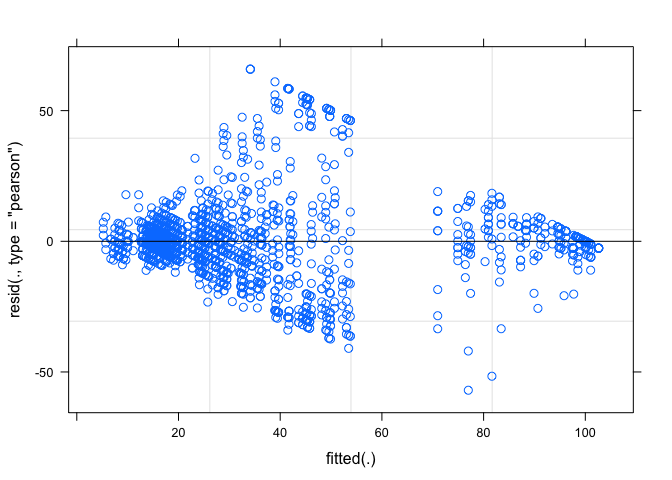

```r
#Model 2 fitting (fitted vs residuals)
plot(fit2_20C)
```

```r
#lsmeans for model 2
lsmeans_fit2_20C <- lsmeans(fit2_20C,"Species")
```

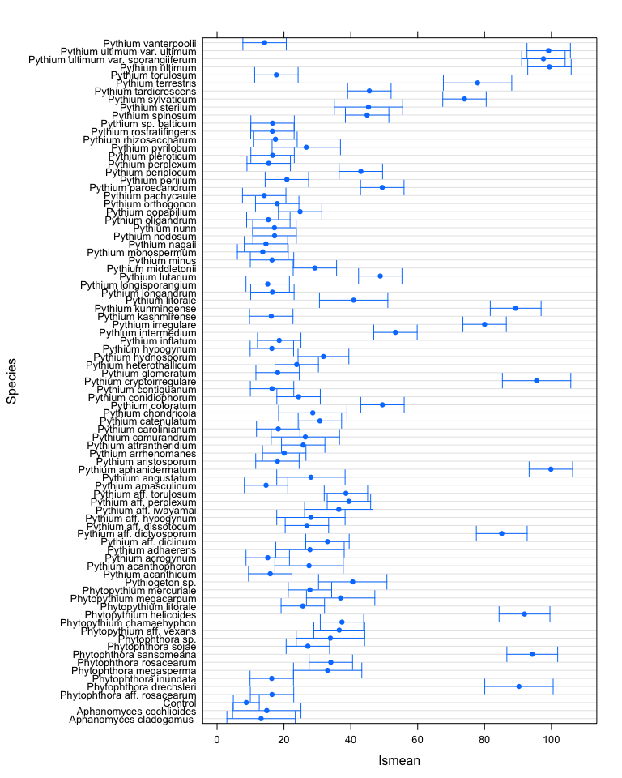

```r
#Print summary for data including mean, SE, df, CIs, t-ratio and p.value
#summary(lsmeans_fit2_20C, infer=c(TRUE,TRUE), adjust="bon")

plot(lsmeans_fit2_20C)
```

```r
#Estimate confidence intervals for model 2
#confint(contrast(lsmeans_fit2, "trt.vs.ctrl", ref=3))
```

```r
#Model 3 with fixed effect (species) and random effect (set) and nested effect (species:isolate)
fit3_20C <- lmer(DIx100 ~ Species + (1|Set) + (1|Species:Isolate), data=Seed_20C, REML = FALSE)
summary(fit3_20C)
```

```
## Linear mixed model fit by maximum likelihood  ['lmerMod']
## Formula: DIx100 ~ Species + (1 | Set) + (1 | Species:Isolate)
##    Data: Seed_20C
##
##      AIC      BIC   logLik deviance df.resid
##  14087.0  14576.6  -6955.5  13911.0     1838
##
## Scaled residuals:
##     Min      1Q  Median      3Q     Max
## -5.5596 -0.4524 -0.0285  0.4412  5.2998
##
## Random effects:
##  Groups          Name        Variance Std.Dev.
##  Species:Isolate (Intercept) 159.590  12.633
##  Set             (Intercept)   9.782   3.128
##  Residual                     54.807   7.403
## Number of obs: 1926, groups:  Species:Isolate, 208; Set, 21
##
## Fixed effects:
##                                            Estimate Std. Error t value
## (Intercept)                                  11.522     12.960   0.889
## SpeciesAphanomyces cochlioides                3.823     18.320   0.209
## SpeciesControl                               -2.791     18.110  -0.154
## SpeciesPhytophthora aff. rosacearum           5.397     15.005   0.360
## SpeciesPhytophthora drechsleri               78.798     18.320   4.301
## SpeciesPhytophthora inundata                  5.010     15.005   0.334
## SpeciesPhytophthora megasperma               21.575     18.320   1.178
## SpeciesPhytophthora rosacearum               22.990     15.005   1.532
## SpeciesPhytophthora sansomeana               81.111     15.765   5.145
## SpeciesPhytophthora sojae                    13.981     14.863   0.941
## SpeciesPhytophthora sp.                      22.409     18.320   1.223
## SpeciesPhytopythium aff. vexans              25.048     15.899   1.575
## SpeciesPhytopythium chamaehyphon             26.323     15.005   1.754
## SpeciesPhytopythium helicoides               80.464     15.899   5.061
## SpeciesPhytopythium litorale                 14.758     15.005   0.984
## SpeciesPhytopythium megacarpum               25.464     18.320   1.390
## SpeciesPhytopythium mercuriale               16.887     15.005   1.125
## SpeciesPythiogeton sp.                       29.075     18.320   1.587
## SpeciesPythium acanthicum                     4.939     15.005   0.329
## SpeciesPythium acanthophoron                 16.020     18.320   0.874
```

[output cut: 50 more lines]

```
## SpeciesPythium pleroticum                     4.799     15.005   0.320
## SpeciesPythium pyrilobum                     15.187     18.320   0.829
## SpeciesPythium rhizosaccharum                 6.121     15.005   0.408
## SpeciesPythium rostratifingens                5.587     15.005   0.372
## SpeciesPythium sp. balticum                   4.799     15.005   0.320
## SpeciesPythium spinosum                      33.920     15.005   2.261
## SpeciesPythium sterilum                      33.798     18.320   1.845
## SpeciesPythium sylvaticum                    60.833     14.863   4.093
## SpeciesPythium tardicrescens                 34.665     15.005   2.310
## SpeciesPythium terrestris                    66.879     18.320   3.651
## SpeciesPythium torulosum                      6.399     15.005   0.426
## SpeciesPythium ultimum                       88.457     15.005   5.895
## SpeciesPythium ultimum var. sporangiiferum   84.444     14.863   5.682
## SpeciesPythium ultimum var. ultimum          86.019     14.863   5.787
## SpeciesPythium vanterpoolii                   3.175     15.005   0.212
```

```
##
## Correlation matrix not shown by default, as p = 85 > 20.
## Use print(x, correlation=TRUE)  or
##   vcov(x)     if you need it
```

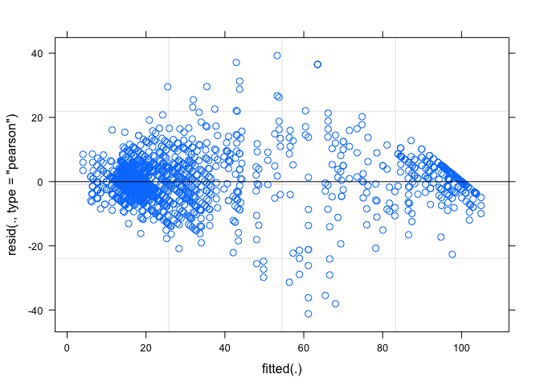

```r
#Model 3 fitting (fitted vs residuals)
plot(fit3_20C)
```

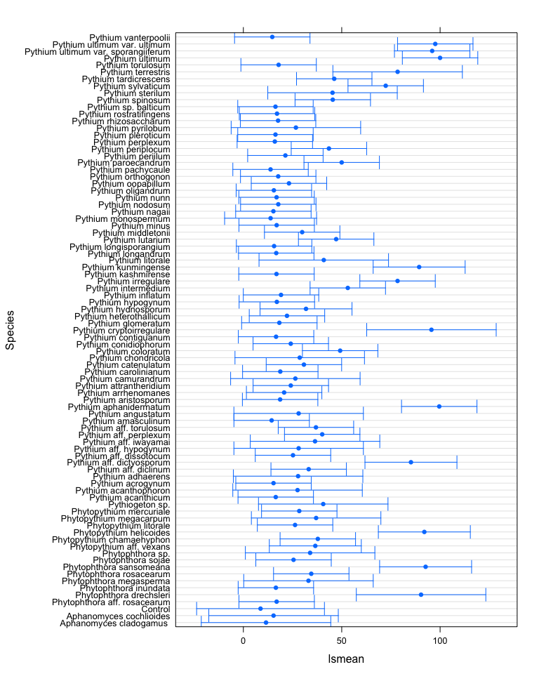

```r
#lsmeans for model 3
lsmeans_fit3_20C <- lsmeans(fit3_20C, "Species")

#Print summary for data including mean, SE, df, CIs, t-ratio and p.value
#summary(lsmeans_fit3_20C, infer=c(TRUE,TRUE), adjust="bon")

plot(lsmeans_fit3_20C)
```

```r
#Comparing models 2 and 3
anova(fit2_20C, fit3_20C)
```

```
## Data: Seed_20C
## Models:
## fit2_20C: DIx100 ~ Species + (1 | Set)
## fit3_20C: DIx100 ~ Species + (1 | Set) + (1 | Species:Isolate)
##          Df   AIC   BIC  logLik deviance  Chisq Chi Df Pr(>Chisq)
## fit2_20C 87 15967 16451 -7896.6    15793
## fit3_20C 88 14087 14577 -6955.5    13911 1882.2      1  < 2.2e-16 ***
## ---
## Signif. codes:  0 '***' 0.001 '**' 0.01 '*' 0.05 '.' 0.1 ' ' 1
```

Based on the model 3, which is the best model, the data was compared against the control to determine those species that are different. The p-values were adjusted with bonferroni due to large number of levels.

```r
#Contrast for model 3
CvsA_fit3_20C <- contrast(lsmeans_fit3_20C, "trt.vs.ctrl", ref=3)
Results_fit3_20C <- summary(CvsA_fit3_20C, adjust="bon")
kable(Results_fit3_20C, digits = 3, format = "markdown")
```

| contrast | estimate | SE | df | t.ratio | p.value |
| --- | --- | --- | --- | --- | --- |
| Aphanomyces cladogamus - Control | 2.791 | 23.490 | 364.281 | 0.119 | 1.000 |
| Aphanomyces cochlioides - Control | 6.615 | 23.490 | 364.243 | 0.282 | 1.000 |
| Phytophthora aff. rosacearum - Control | 8.189 | 19.152 | 363.376 | 0.428 | 1.000 |
| Phytophthora drechsleri - Control | 81.589 | 23.490 | 364.243 | 3.473 | 0.048 |
| Phytophthora inundata - Control | 7.801 | 19.152 | 363.376 | 0.407 | 1.000 |
| Phytophthora megasperma - Control | 24.367 | 23.490 | 364.243 | 1.037 | 1.000 |
| Phytophthora rosacearum - Control | 25.781 | 19.152 | 363.376 | 1.346 | 1.000 |
| Phytophthora sansomeana - Control | 83.903 | 20.324 | 363.717 | 4.128 | 0.004 |
| Phytophthora sojae - Control | 16.773 | 19.152 | 363.433 | 0.876 | 1.000 |
| Phytophthora sp. - Control | 25.200 | 23.490 | 364.243 | 1.073 | 1.000 |
| Phytopythium aff. vexans - Control | 27.839 | 20.324 | 363.667 | 1.370 | 1.000 |
| Phytopythium chamaehyphon - Control | 29.115 | 19.152 | 363.376 | 1.520 | 1.000 |
| Phytopythium helicoides - Control | 83.256 | 20.324 | 363.667 | 4.097 | 0.004 |
| Phytopythium litorale - Control | 17.549 | 19.152 | 363.384 | 0.916 | 1.000 |
| Phytopythium megacarpum - Control | 28.256 | 23.490 | 364.243 | 1.203 | 1.000 |
| Phytopythium mercuriale - Control | 19.679 | 19.152 | 363.384 | 1.028 | 1.000 |
| Pythiogeton sp. - Control | 31.867 | 23.490 | 364.243 | 1.357 | 1.000 |
| Pythium acanthicum - Control | 7.730 | 19.152 | 363.333 | 0.404 | 1.000 |
| Pythium acanthophoron - Control | 18.811 | 23.490 | 364.243 | 0.801 | 1.000 |
| Pythium acrogynum - Control | 6.598 | 19.152 | 363.376 | 0.344 | 1.000 |
| Pythium adhaerens - Control | 19.089 | 23.490 | 364.243 | 0.813 | 1.000 |
| Pythium aff. diclinum - Control | 24.468 | 19.152 | 363.376 | 1.278 | 1.000 |
| Pythium aff. dictyosporum - Control | 76.450 | 20.324 | 363.667 | 3.762 | 0.017 |
| Pythium aff. dissotocum - Control | 16.495 | 19.152 | 363.433 | 0.861 | 1.000 |
| Pythium aff. hypogynum - Control | 19.367 | 23.490 | 364.243 | 0.824 | 1.000 |
| Pythium aff. iwayamai - Control | 27.700 | 23.490 | 364.243 | 1.179 | 1.000 |
| Pythium aff. perplexum - Control | 31.346 | 19.152 | 363.384 | 1.637 | 1.000 |
| Pythium aff. torulosum - Control | 28.162 | 19.152 | 363.433 | 1.470 | 1.000 |
| Pythium amasculinum - Control | 5.646 | 19.152 | 363.384 | 0.295 | 1.000 |
| Pythium angustatum - Control | 19.367 | 23.490 | 364.243 | 0.824 | 1.000 |

[output cut: 54 more lines]

### Seed rot data for 13C

Subsetting the 13C seed rot assay data for statistical analysis, and testing different models to find the best fit:

- Species as fixed effect
- Species as fixed effect and experiment as random factor
- Species as fixed effect, experiment as random factor and Isolates nested within species

```r
#Dataset for 20C for seed rot
Seed_13C <- subset(seed, seed$Temp=="13C")
#General model AOV
fit1_13C <- aov(DIx100 ~ Species, data=Seed_13C)
summary(fit1_13C, adjust="bon")
```

```
##               Df  Sum Sq Mean Sq F value Pr(>F)
## Species       84 1553136   18490   64.14 <2e-16 ***
## Residuals   1841  530695     288
## ---
## Signif. codes:  0 '***' 0.001 '**' 0.01 '*' 0.05 '.' 0.1 ' ' 1
```

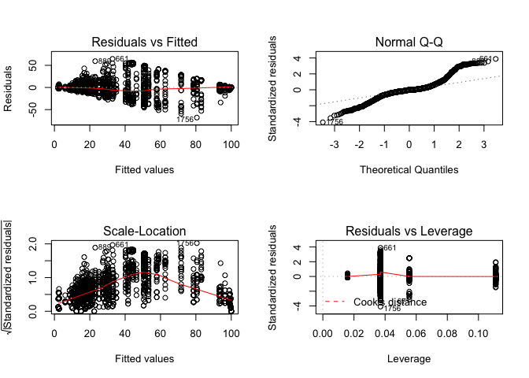

```r
#Plotting diagnostic plots for fit1 model
par(mfrow=c(2,2)) # optional layout
plot(fit1_13C)# diagnostic plots
```

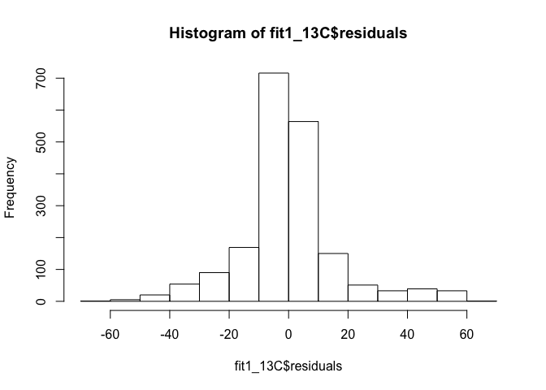

```r
#Plotting residuals
par(mfrow=c(1,1)) # optional layout
hist(fit1_13C$residuals)
```

```r
##Model 2 with fixed effect (species) and random effect (set)
fit2_13C <- lmer(DIx100 ~ Species + (1|Set), data=Seed_13C, REML = FALSE)
summary(fit2_13C)
```

```
## Linear mixed model fit by maximum likelihood  ['lmerMod']
## Formula: DIx100 ~ Species + (1 | Set)
##    Data: Seed_13C
##
##      AIC      BIC   logLik deviance df.resid
##  16456.2  16940.2  -8141.1  16282.2     1839
##
## Scaled residuals:
##     Min      1Q  Median      3Q     Max
## -4.0748 -0.3724 -0.0465  0.2785  3.8864
##
## Random effects:
##  Groups   Name        Variance Std.Dev.
##  Set      (Intercept)   2.534   1.592
##  Residual             272.955  16.521
## Number of obs: 1926, groups:  Set, 21
##
## Fixed effects:
##                                            Estimate Std. Error t value
## (Intercept)                                 8.62079    5.58152   1.545
## SpeciesAphanomyces cochlioides              2.19964    7.89305   0.279
## SpeciesControl                             -6.04142    5.94688  -1.016
## SpeciesPhytophthora aff. rosacearum         6.36631    6.48702   0.981
## SpeciesPhytophthora drechsleri              4.46703    7.89305   0.566
## SpeciesPhytophthora inundata                6.09606    6.48702   0.940
## SpeciesPhytophthora megasperma              3.91147    7.89305   0.496
## SpeciesPhytophthora rosacearum             42.66260    6.48702   6.577
## SpeciesPhytophthora sansomeana             50.27778    6.74481   7.454
## SpeciesPhytophthora sojae                  -6.38889    6.35907  -1.005
## SpeciesPhytophthora sp.                     3.35591    7.89305   0.425
## SpeciesPhytopythium aff. vexans             3.49480    6.86558   0.509
## SpeciesPhytopythium chamaehyphon           24.23668    6.48702   3.736
## SpeciesPhytopythium helicoides             13.91147    6.86558   2.026
## SpeciesPhytopythium litorale               24.71470    6.48702   3.810
## SpeciesPhytopythium megacarpum              6.96703    7.89305   0.883
## SpeciesPhytopythium mercuriale             22.12210    6.48702   3.410
## SpeciesPythiogeton sp.                     37.80036    7.89305   4.789
## SpeciesPythium acanthicum                  12.22222    6.48702   1.884
## SpeciesPythium acanthophoron                1.41147    7.89305   0.179
## SpeciesPythium acrogynum                   14.42939    6.48702   2.224
```

[output cut: 49 more lines]

```
## SpeciesPythium pleroticum                  13.01039    6.48702   2.006
## SpeciesPythium pyrilobum                   26.41147    7.89305   3.346
## SpeciesPythium rhizosaccharum               6.37383    6.48702   0.983
## SpeciesPythium rostratifingens              9.07407    6.48702   1.399
## SpeciesPythium sp. balticum                33.01039    6.48702   5.089
## SpeciesPythium spinosum                    71.94444    6.48702  11.091
## SpeciesPythium sterilum                    21.41147    7.89305   2.713
## SpeciesPythium sylvaticum                  90.83333    6.35907  14.284
## SpeciesPythium tardicrescens               33.51099    6.48702   5.166
## SpeciesPythium terrestris                  90.53297    7.89305  11.470
## SpeciesPythium torulosum                   20.91087    6.48702   3.223
## SpeciesPythium ultimum                     90.55556    6.48702  13.960
## SpeciesPythium ultimum var. sporangiiferum 87.87037    6.35907  13.818
## SpeciesPythium ultimum var. ultimum        91.20370    6.35907  14.342
## SpeciesPythium vanterpoolii                20.07001    6.48702   3.094
```

```
##
## Correlation matrix not shown by default, as p = 85 > 20.
## Use print(x, correlation=TRUE)  or
##   vcov(x)     if you need it
```

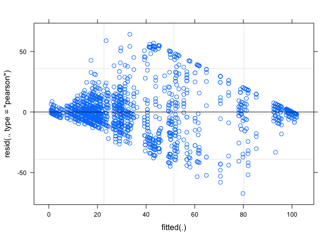

```r
#Model 2 fitting (fitted vs residuals)
plot(fit2_13C)
```

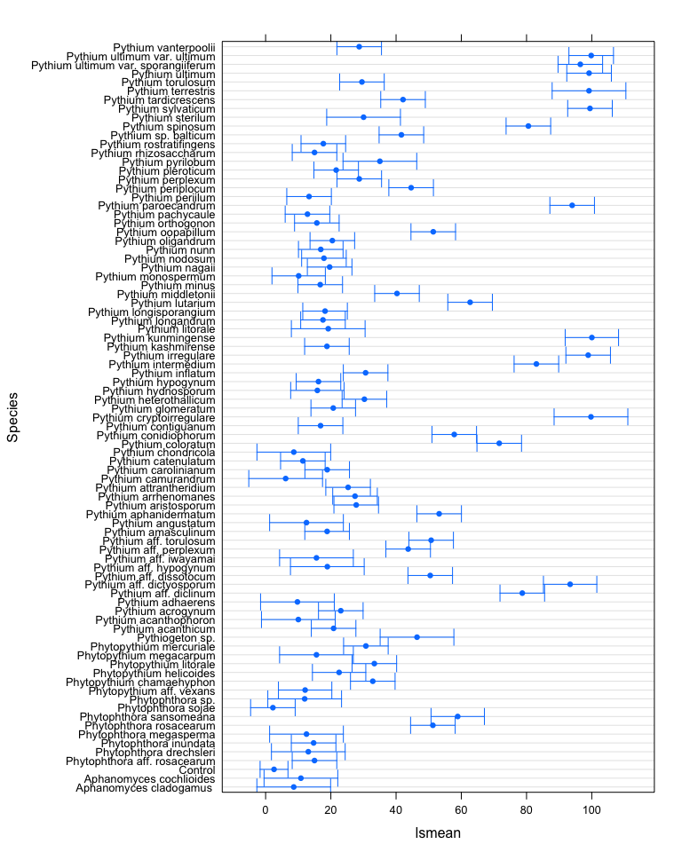

```r
#lsmeans for model 2
lsmeans_fit2_13C <- lsmeans(fit2_13C,"Species")

#Print summary for data including mean, SE, df, CIs, t-ratio and p.value
#summary(lsmeans_fit2_13C, infer=c(TRUE,TRUE), adjust="bon")

plot(lsmeans_fit2_13C)
```

```r
#Estimate confidence intervals for model 2
#confint(contrast(lsmeans_fit2, "trt.vs.ctrl", ref=3))
```

```r
#Model 3 with fixed effect (species) and random effect (set) and nested effect (species:isolate)
fit3_13C <- lmer(DIx100 ~ Species + (1|Set) + (1|Species:Isolate), data=Seed_13C, REML = FALSE)
summary(fit3_13C)
```

```
## Linear mixed model fit by maximum likelihood  ['lmerMod']
## Formula: DIx100 ~ Species + (1 | Set) + (1 | Species:Isolate)
##    Data: Seed_13C
##
##      AIC      BIC   logLik deviance df.resid
##  14821.9  15311.5  -7323.0  14645.9     1838
##
## Scaled residuals:
##     Min      1Q  Median      3Q     Max
## -4.9567 -0.4647 -0.0336  0.3953  5.8344
##
## Random effects:
##  Groups          Name        Variance Std.Dev.
##  Species:Isolate (Intercept) 194.765  13.956
##  Set             (Intercept)   5.878   2.424
##  Residual                     82.648   9.091
## Number of obs: 1926, groups:  Species:Isolate, 208; Set, 21
##
## Fixed effects:
##                                            Estimate Std. Error t value
## (Intercept)                                  8.6739    14.3392   0.605
## SpeciesAphanomyces cochlioides               2.0757    20.2763   0.102
## SpeciesControl                              -6.0945    20.0352  -0.304
## SpeciesPhytophthora aff. rosacearum          6.2424    16.5880   0.376
## SpeciesPhytophthora drechsleri               4.5910    20.2763   0.226
## SpeciesPhytophthora inundata                 6.0134    16.5880   0.363
## SpeciesPhytophthora megasperma               4.0354    20.2763   0.199
## SpeciesPhytophthora rosacearum              42.5387    16.5880   2.564
## SpeciesPhytophthora sansomeana              50.2778    17.4906   2.875
## SpeciesPhytophthora sojae                   -6.3889    16.4903  -0.387
## SpeciesPhytophthora sp.                      3.4799    20.2763   0.172
## SpeciesPhytopythium aff. vexans              3.6187    17.5827   0.206
## SpeciesPhytopythium chamaehyphon            24.1127    16.5880   1.454
## SpeciesPhytopythium helicoides              14.0354    17.5827   0.798
## SpeciesPhytopythium litorale                24.6734    16.5880   1.487
## SpeciesPhytopythium megacarpum               7.0910    20.2763   0.350
## SpeciesPhytopythium mercuriale              22.0808    16.5880   1.331
## SpeciesPythiogeton sp.                      37.9243    20.2763   1.870
## SpeciesPythium acanthicum                   12.2222    16.5880   0.737
## SpeciesPythium acanthophoron                 1.5354    20.2763   0.076
```

[output cut: 50 more lines]

```
## SpeciesPythium pleroticum                   12.7625    16.5880   0.769
## SpeciesPythium pyrilobum                    26.5354    20.2763   1.309
## SpeciesPythium rhizosaccharum                6.2912    16.5880   0.379
## SpeciesPythium rostratifingens               9.0741    16.5880   0.547
## SpeciesPythium sp. balticum                 32.7625    16.5880   1.975
## SpeciesPythium spinosum                     71.9444    16.5880   4.337
## SpeciesPythium sterilum                     21.5354    20.2763   1.062
## SpeciesPythium sylvaticum                   90.8333    16.4903   5.508
## SpeciesPythium tardicrescens                33.4697    16.5880   2.018
## SpeciesPythium terrestris                   90.4090    20.2763   4.459
## SpeciesPythium torulosum                    20.8282    16.5880   1.256
## SpeciesPythium ultimum                      90.5556    16.5880   5.459
## SpeciesPythium ultimum var. sporangiiferum  87.8704    16.4903   5.329
## SpeciesPythium ultimum var. ultimum         91.2037    16.4903   5.531
## SpeciesPythium vanterpoolii                 19.9461    16.5880   1.202
```

```
##
## Correlation matrix not shown by default, as p = 85 > 20.
## Use print(x, correlation=TRUE)  or
##   vcov(x)     if you need it
```

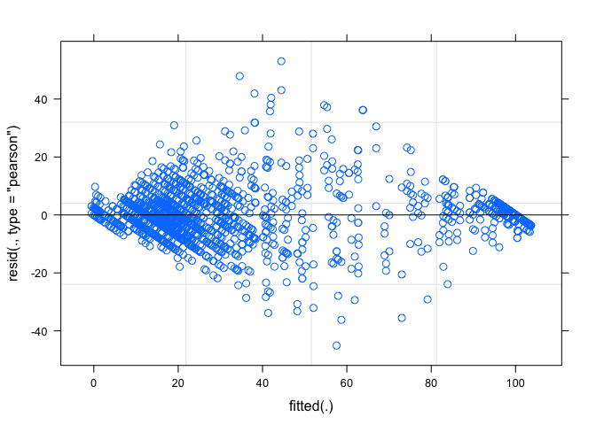

```r
#Model 3 fitting (fitted vs residuals)
plot(fit3_13C)
```

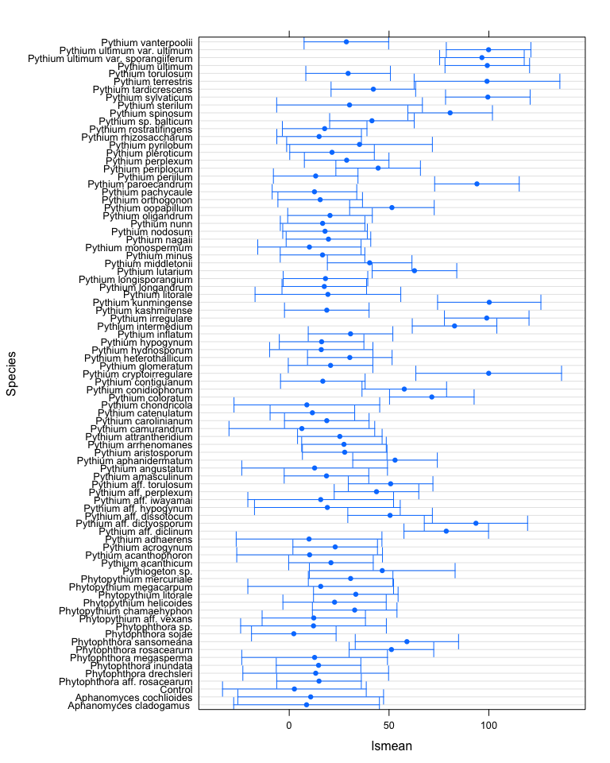

```r
#lsmeans for model 3
lsmeans_fit3_13C <- lsmeans(fit3_13C, "Species")

#Print summary for data including mean, SE, df, CIs, t-ratio and p.value
#summary(lsmeans_fit3_13C, infer=c(TRUE,TRUE), adjust="bon")

plot(lsmeans_fit3_13C)
```

```r
#Comparing models 2 and 3
anova(fit2_13C, fit3_13C)
```

```
## Data: Seed_13C
## Models:
## fit2_13C: DIx100 ~ Species + (1 | Set)
## fit3_13C: DIx100 ~ Species + (1 | Set) + (1 | Species:Isolate)
##          Df   AIC   BIC  logLik deviance  Chisq Chi Df Pr(>Chisq)
## fit2_13C 87 16456 16940 -8141.1    16282
## fit3_13C 88 14822 15312 -7323.0    14646 1636.3      1  < 2.2e-16 ***
## ---
## Signif. codes:  0 '***' 0.001 '**' 0.01 '*' 0.05 '.' 0.1 ' ' 1
```

Based on the model 3, which is the best model, the data was compared against the control to determine those species that are different. The p-values were adjusted with bonferroni due to large number of levels.

```r
#Contrast for model 3
CvsA_fit3_13C <- contrast(lsmeans_fit3_13C, "trt.vs.ctrl", ref=3)
Results_fit3_13C <- summary(CvsA_fit3_13C, adjust="bon", level=.90)
kable(Results_fit3_13C, format = "markdown")
```

| contrast | estimate | SE | df | t.ratio | p.value |
| --- | --- | --- | --- | --- | --- |
| Aphanomyces cladogamus - Control | 6.0945436 | 26.05928 | 354.8147 | 0.2338723 | 1.0000000 |
| Aphanomyces cochlioides - Control | 8.1702382 | 26.05928 | 354.7950 | 0.3135251 | 1.0000000 |
| Phytophthora aff. rosacearum - Control | 12.3369048 | 21.22774 | 353.7264 | 0.5811689 | 1.0000000 |
| Phytophthora drechsleri - Control | 10.6855157 | 26.05928 | 354.7950 | 0.4100464 | 1.0000000 |
| Phytophthora inundata - Control | 12.1079696 | 21.22774 | 353.7264 | 0.5703842 | 1.0000000 |
| Phytophthora megasperma - Control | 10.1299601 | 26.05928 | 354.7950 | 0.3887275 | 1.0000000 |
| Phytophthora rosacearum - Control | 48.6332011 | 21.22774 | 353.7264 | 2.2910207 | 1.0000000 |
| Phytophthora sansomeana - Control | 56.3723214 | 22.53296 | 354.1110 | 2.5017715 | 1.0000000 |
| Phytophthora sojae - Control | -0.2943453 | 21.22774 | 353.7557 | -0.0138661 | 1.0000000 |
| Phytophthora sp. - Control | 9.5744045 | 26.05928 | 354.7950 | 0.3674086 | 1.0000000 |
| Phytopythium aff. vexans - Control | 9.7132934 | 22.53296 | 354.0849 | 0.4310704 | 1.0000000 |
| Phytopythium chamaehyphon - Control | 30.2072752 | 21.22774 | 353.7264 | 1.4230092 | 1.0000000 |
| Phytopythium helicoides - Control | 20.1299601 | 22.53296 | 354.0849 | 0.8933561 | 1.0000000 |
| Phytopythium litorale - Control | 30.7679233 | 21.22774 | 353.7307 | 1.4494203 | 1.0000000 |
| Phytopythium megacarpum - Control | 13.1855157 | 26.05928 | 354.7950 | 0.5059815 | 1.0000000 |
| Phytopythium mercuriale - Control | 28.1753307 | 21.22774 | 353.7307 | 1.3272880 | 1.0000000 |
| Pythiogeton sp. - Control | 44.0188490 | 26.05928 | 354.7950 | 1.6891812 | 1.0000000 |
| Pythium acanthicum - Control | 18.3167658 | 21.22774 | 353.7048 | 0.8628692 | 1.0000000 |
| Pythium acanthophoron - Control | 7.6299601 | 26.05928 | 354.7950 | 0.2927924 | 1.0000000 |
| Pythium acrogynum - Control | 20.4413029 | 21.22774 | 353.7264 | 0.9629522 | 1.0000000 |
| Pythium adhaerens - Control | 7.3521823 | 26.05928 | 354.7950 | 0.2821330 | 1.0000000 |
| Pythium aff. diclinum - Control | 76.0894511 | 21.22774 | 353.7264 | 3.5844342 | 0.0323584 |
| Pythium aff. dictyosporum - Control | 90.9632934 | 22.53296 | 354.0849 | 4.0368991 | 0.0055791 |
| Pythium aff. dissotocum - Control | 47.9463954 | 21.22774 | 353.7557 | 2.2586665 | 1.0000000 |
| Pythium aff. hypogynum - Control | 16.5188490 | 26.05928 | 354.7950 | 0.6338950 | 1.0000000 |
| Pythium aff. iwayamai - Control | 13.1855157 | 26.05928 | 354.7950 | 0.5059815 | 1.0000000 |
| Pythium aff. perplexum - Control | 41.1382936 | 21.22774 | 353.7307 | 1.9379494 | 1.0000000 |
| Pythium aff. torulosum - Control | 48.2241732 | 21.22774 | 353.7557 | 2.2717521 | 1.0000000 |
| Pythium amasculinum - Control | 16.0792661 | 21.22774 | 353.7307 | 0.7574647 | 1.0000000 |
| Pythium angustatum - Control | 10.1299601 | 26.05928 | 354.7950 | 0.3887275 | 1.0000000 |

[output cut: 54 more lines]

## Clustering for seed rot data

```r
#Sorting tables for seed rot at 13C and 20C
Seed_13C <- Seed_13C[order(Seed_13C[,1], Seed_13C[,2], Seed_13C[,3]),]
Seed_20C <- Seed_20C[order(Seed_20C[,1], Seed_20C[,2], Seed_20C[,3]),]

#Join tables using isolate, species, set and replicate
Seed_temps <- left_join(Seed_13C,Seed_20C,by=c("Isolate","Species","Set","Rep"))
Seed_temps <- Seed_temps %>% dplyr::select(Set, Isolate, Rep, Species, Temp.x, Temp.y, DIx100.x, DIx100.y)
#Sanity check
#dim(Seed_temps)

#Relabel columns for analysis
Seed_temps <- rename(Seed_temps, Temp13C=Temp.x, Temp_20C=Temp.y, DI_13C=DIx100.x,  DI_20C=DIx100.y)
head(Seed_temps)
```

```
##       Set        Isolate Rep                 Species Temp13C Temp_20C
## 1 Set_1-1  AR_15.S.2.7.A  R1  Pythium aff. torulosum     13C      20C
## 2 Set_1-1  AR_15.S.2.7.A  R2  Pythium aff. torulosum     13C      20C
## 3 Set_1-1  AR_15.S.2.7.A  R3  Pythium aff. torulosum     13C      20C
## 4 Set_1-1 AR_160.S.1.9.A  R1 Pythium aff. dissotocum     13C      20C
## 5 Set_1-1 AR_160.S.1.9.A  R2 Pythium aff. dissotocum     13C      20C
## 6 Set_1-1 AR_160.S.1.9.A  R3 Pythium aff. dissotocum     13C      20C
##   DI_13C DI_20C
## 1  100.0   57.5
## 2  100.0   72.5
## 3  100.0   70.0
## 4   97.5   35.0
## 5   82.5   45.0
## 6   90.0   55.0
```

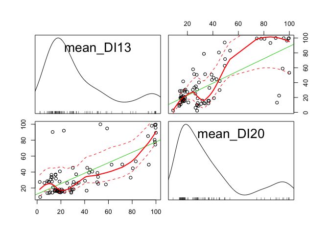

```r
#lda
#r <- lda(formula=Species ~ DI_13C + DI_20C, data=Seed_temps)

#Summarizing data using different parameters by plyr library
seed_lda_isol <- ddply(Seed_temps, c("Species"), summarise,
              N = length(DI_13C),
              mean_DI13 = mean(DI_13C),
              std_DI13 = std(DI_13C),
              mean_DI20 = mean(DI_20C),
              std_DI20 = std(DI_20C)
              )

library(car)
#Clustering by isolate
scatterplotMatrix(seed_lda_isol[c(3,5)])
```

[figure not shown]

```r
#Hierarchical clustering
library(ape)
seed_cluster <- seed_lda_isol[,-c(2,4,6)]
rownames(seed_cluster) <- make.names(seed_cluster[,1], unique = TRUE)
seed_cluster <- seed_cluster[,-1]

d_isol <- dist(seed_cluster, method="euclidean")
fit_isol <- hclust(d_isol, method="ward.D")
plot(fit_isol)
groups_isol <- cutree(fit_isol, k=3)
rect.hclust(fit_isol,k=3, border="red")
```

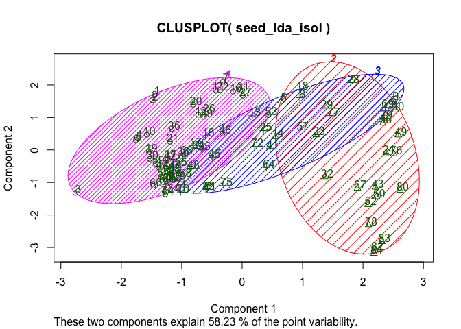

```r
###Clustering with a different package
library(plyr)
seed_rot_isol <- cbind(seed_lda_isol,groups_isol)
cluster_seed_rot <- gather(seed_rot_isol, Temp, DI, c(mean_DI13, mean_DI20))
cluster_seed_rot$groups_isol <- as.factor(cluster_seed_rot$groups_isol)
#Change levels
cluster_seed_rot$groups_isol <- revalue(cluster_seed_rot$groups_isol, c("1" = "A", "2"="C", "3"="B"))
#Reorder levels
cluster_seed_rot$groups_isol <- ordered(cluster_seed_rot$groups_isol, levels=c("A","B","C"))

library(ggplot2)
bp <- ggplot(data=cluster_seed_rot, aes(x=groups_isol, y=DI)) +
  geom_boxplot(aes(fill=Temp), position=position_dodge(width=1)) +
  labs(x="Clusters", y="Disease Severity Index") +
  scale_fill_discrete(labels=c("13ºC","20ºC"))

# library(mclust)
# set.seed(0)
# fit2 <- Mclust(seed_lda)
# summary(fit2)

library(cluster)
clusplot(seed_lda_isol,groups_isol, color = TRUE, shade = TRUE, labels=2, lines=0)
```

```r
#kable(seed_lda_)
```

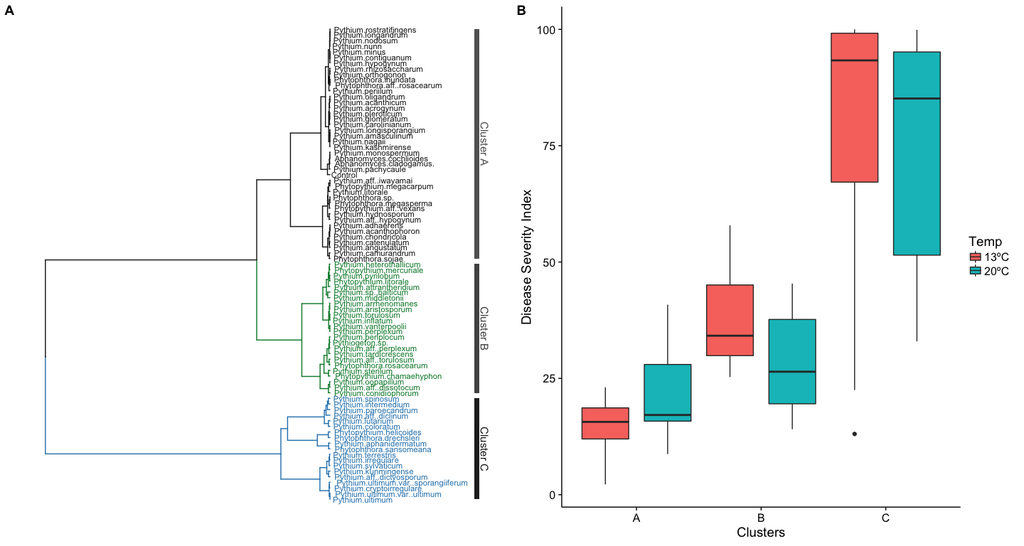

```r
library(ggtree)
library(cowplot)
#mypal = c("#1a1a1a","#008837","#2b83ba")
#htree <- plot(as.phylo(fit_isol), cex=0.6, type="phylogram", tip.color = mypal[groups_isol])
P <- as.phylo(fit_isol)
P <- groupClade(P, node=c(90, 89, 87))
htree2 <- ggtree(P, aes(colour=group), size=0.5) + geom_text(aes(label=label), size=3, hjust=-0.05) +
  scale_color_manual(values = c("#1a1a1a","#1a1a1a","#008837","#2b83ba"))

htree2.1 <- htree2 %>%
  annotation_clade(node=90, "Cluster A", offset.text = 20, offset = 400, color="#636363") %>%
  annotation_clade(node=89, "Cluster B", offset.text = 20, offset = 400, color="#525252") %>%
  annotation_clade(node=87, "Cluster C", offset.text = 20, offset = 400, color="#252525")

plot_grid(htree2.1, bp, labels=c("A","B"), ncol=2)
```

```r
#library(ggdendro)
#ggdendrogram(fit_isol, size=1, color="tomato")
```

### Summary table Seed rot data

```r
seed_spp <- ddply(Seed_temps, c("Species"), summarise,
              N = length(DI_13C)/9,
              mean_DI13 = mean(DI_13C),
              std_DI13 = std(DI_13C),
              mean_DI20 = mean(DI_20C),
              std_DI20 = std(DI_20C)
              )

#Transforming dataframes to remove " - " and split the column into species and control (reference for comparison)
library(reshape2)
DI_13C <- separate(Results_fit3_13C, contrast, into = c("Species", "Control"), " - ")
DI_20C <- separate(Results_fit3_20C, contrast, into = c("Species", "Control"), " - ")

#merge tables together
Seed_pvalue <- left_join(DI_13C,DI_20C,by="Species")

#Rename important columns
Seed_pvalue<- rename(Seed_pvalue, Control=Control.x,
                     Estimate_13C=estimate.x,
                     Pval_13C=p.value.x,
                     Estimate_20C=estimate.y,
                     Pval_20C=p.value.y
                     )

#Merge last table
Seed_pvalue <- left_join(Seed_pvalue,seed_spp, by="Species")
Seed_rot_final <- Seed_pvalue %>% dplyr::select(Species,
                                                N,
                                                mean_DI13,
                                                std_DI13,
                                                Pval_13C,
                                                mean_DI20,
                                                std_DI20,
                                                Pval_20C
                                                )
kable(Seed_rot_final, format = "markdown")
```

| Species | N | mean_DI13 | std_DI13 | Pval_13C | mean_DI20 | std_DI20 | Pval_20C |
| --- | --- | --- | --- | --- | --- | --- | --- |
| Aphanomyces cladogamus | 1 | 8.611111 | 1.4500426 | 1.0000000 | 13.61111 | 1.9144512 | 1.0000000 |
| Aphanomyces cochlioides | 1 | 10.833333 | 0.9316950 | 1.0000000 | 14.72222 | 1.7402728 | 1.0000000 |
| Phytophthora aff. rosacearum | 3 | 15.000000 | 1.0591482 | 1.0000000 | 16.29630 | 0.8582843 | 1.0000000 |
| Phytophthora drechsleri | 1 | 13.055556 | 3.1944444 | 1.0000000 | 90.27778 | 2.0174776 | 0.0483834 |
| Phytophthora inundata | 3 | 14.722222 | 1.1810268 | 1.0000000 | 16.29630 | 0.6450884 | 1.0000000 |
| Phytophthora megasperma | 1 | 12.500000 | 1.5023130 | 1.0000000 | 33.05556 | 4.7099514 | 1.0000000 |
| Phytophthora rosacearum | 3 | 51.296296 | 6.9020549 | 1.0000000 | 33.88889 | 3.9502185 | 1.0000000 |
| Phytophthora sansomeana | 2 | 58.888889 | 10.0065792 | 1.0000000 | 94.72222 | 1.3081083 | 0.0038097 |
| Phytophthora sojae | 3 | 2.222222 | 0.2777778 | 1.0000000 | 27.59259 | 2.0949738 | 1.0000000 |
| Phytophthora sp. | 1 | 11.944444 | 1.7066952 | 1.0000000 | 33.88889 | 3.7985540 | 1.0000000 |
| Phytopythium aff. vexans | 2 | 12.083333 | 1.4469090 | 1.0000000 | 36.52778 | 2.8015729 | 1.0000000 |
| Phytopythium chamaehyphon | 3 | 32.870370 | 3.9780015 | 1.0000000 | 37.22222 | 3.6012357 | 1.0000000 |
| Phytopythium helicoides | 2 | 22.500000 | 1.8959882 | 1.0000000 | 91.94444 | 1.6112801 | 0.0043462 |
| Phytopythium litorale | 3 | 33.333333 | 3.1997819 | 1.0000000 | 25.46296 | 1.5677769 | 1.0000000 |
| Phytopythium megacarpum | 1 | 15.555556 | 1.9444444 | 1.0000000 | 36.94444 | 4.1411254 | 1.0000000 |
| Phytopythium mercuriale | 3 | 30.740741 | 1.6816358 | 1.0000000 | 27.59259 | 1.6260077 | 1.0000000 |
| Pythiogeton sp. | 1 | 46.388889 | 6.4966753 | 1.0000000 | 40.55556 | 2.5609846 | 1.0000000 |
| Pythium acanthicum | 3 | 20.833333 | 1.0840727 | 1.0000000 | 15.74074 | 0.7162990 | 1.0000000 |
| Pythium acanthophoron | 1 | 10.000000 | 1.2500000 | 1.0000000 | 27.50000 | 2.8867513 | 1.0000000 |
| Pythium acrogynum | 3 | 23.055556 | 3.0642843 | 1.0000000 | 15.09259 | 0.7367234 | 1.0000000 |
| Pythium adhaerens | 1 | 9.722222 | 1.2804923 | 1.0000000 | 27.77778 | 4.9378858 | 1.0000000 |
| Pythium aff. diclinum | 3 | 78.703704 | 2.5013186 | 0.0323584 | 32.96296 | 5.2823367 | 1.0000000 |
| Pythium aff. dictyosporum | 2 | 93.333333 | 1.1433239 | 0.0055791 | 85.13889 | 4.2225286 | 0.0165204 |
| Pythium aff. dissotocum | 3 | 50.462963 | 5.1179761 | 1.0000000 | 27.31481 | 2.5139423 | 1.0000000 |
| Pythium aff. hypogynum | 1 | 18.888889 | 3.4638789 | 1.0000000 | 28.05556 | 1.1620278 | 1.0000000 |
| Pythium aff. iwayamai | 1 | 15.555556 | 2.5609846 | 1.0000000 | 36.38889 | 4.1481068 | 1.0000000 |
| Pythium aff. perplexum | 3 | 43.703704 | 7.5994948 | 1.0000000 | 39.25926 | 7.0278937 | 1.0000000 |
| Pythium aff. torulosum | 3 | 50.740741 | 7.2744024 | 1.0000000 | 38.98148 | 4.4040484 | 1.0000000 |
| Pythium amasculinum | 3 | 18.888889 | 1.2612269 | 1.0000000 | 14.72222 | 0.5867321 | 1.0000000 |
| Pythium angustatum | 1 | 12.500000 | 0.7216878 | 1.0000000 | 28.05556 | 6.3571069 | 1.0000000 |

[output cut: 54 more lines]